# Risk Factor Analysis

## Outcome Variable

**Outcome Variable:** ever_wasted

## Predictor Variables

**Intervention Variable:** vagbrth

**Adjustment Set:**

unadjusted

## Stratifying Variables

The analysis was stratified on these variable(s):

- agecat
- studyid
- country

## Data Summary

| agecat | studyid | country | vagbrth | ever_wasted | n_cell | n |
| --- | --- | --- | --- | --- | --- | --- |
| 0-24 months (no birth wast) | CMC-V-BCS-2002 | INDIA | 0 | 0 | 17 | 368 |
| 0-24 months (no birth wast) | CMC-V-BCS-2002 | INDIA | 0 | 1 | 8 | 368 |
| 0-24 months (no birth wast) | CMC-V-BCS-2002 | INDIA | 1 | 0 | 185 | 368 |
| 0-24 months (no birth wast) | CMC-V-BCS-2002 | INDIA | 1 | 1 | 158 | 368 |
| 0-24 months (no birth wast) | IRC | INDIA | 0 | 0 | 38 | 409 |
| 0-24 months (no birth wast) | IRC | INDIA | 0 | 1 | 32 | 409 |
| 0-24 months (no birth wast) | IRC | INDIA | 1 | 0 | 158 | 409 |
| 0-24 months (no birth wast) | IRC | INDIA | 1 | 1 | 181 | 409 |
| 0-24 months (no birth wast) | JiVitA-3 | BANGLADESH | 0 | 0 | 1301 | 26404 |
| 0-24 months (no birth wast) | JiVitA-3 | BANGLADESH | 0 | 1 | 189 | 26404 |
| 0-24 months (no birth wast) | JiVitA-3 | BANGLADESH | 1 | 0 | 20624 | 26404 |
| 0-24 months (no birth wast) | JiVitA-3 | BANGLADESH | 1 | 1 | 4290 | 26404 |
| 0-24 months (no birth wast) | JiVitA-4 | BANGLADESH | 0 | 0 | 291 | 4499 |
| 0-24 months (no birth wast) | JiVitA-4 | BANGLADESH | 0 | 1 | 79 | 4499 |
| 0-24 months (no birth wast) | JiVitA-4 | BANGLADESH | 1 | 0 | 3007 | 4499 |
| 0-24 months (no birth wast) | JiVitA-4 | BANGLADESH | 1 | 1 | 1122 | 4499 |
| 0-24 months (no birth wast) | NIH-Crypto | BANGLADESH | 0 | 0 | 181 | 496 |
| 0-24 months (no birth wast) | NIH-Crypto | BANGLADESH | 0 | 1 | 21 | 496 |
| 0-24 months (no birth wast) | NIH-Crypto | BANGLADESH | 1 | 0 | 245 | 496 |
| 0-24 months (no birth wast) | NIH-Crypto | BANGLADESH | 1 | 1 | 49 | 496 |
| 0-24 months (no birth wast) | PROBIT | BELARUS | 0 | 0 | 1805 | 16879 |
| 0-24 months (no birth wast) | PROBIT | BELARUS | 0 | 1 | 147 | 16879 |
| 0-24 months (no birth wast) | PROBIT | BELARUS | 1 | 0 | 13926 | 16879 |
| 0-24 months (no birth wast) | PROBIT | BELARUS | 1 | 1 | 1001 | 16879 |
| 0-24 months (no birth wast) | PROVIDE | BANGLADESH | 0 | 0 | 132 | 687 |
| 0-24 months (no birth wast) | PROVIDE | BANGLADESH | 0 | 1 | 27 | 687 |
| 0-24 months (no birth wast) | PROVIDE | BANGLADESH | 1 | 0 | 433 | 687 |
| 0-24 months (no birth wast) | PROVIDE | BANGLADESH | 1 | 1 | 95 | 687 |
| 0-24 months (no birth wast) | TanzaniaChild2 | TANZANIA, UNITED REPUBLIC OF | 0 | 0 | 174 | 2355 |
| 0-24 months (no birth wast) | TanzaniaChild2 | TANZANIA, UNITED REPUBLIC OF | 0 | 1 | 38 | 2355 |

[output cut: 78 more lines]

The following strata were considered:

- agecat: 0-24 months (no birth wast), studyid: CMC-V-BCS-2002, country: INDIA
- agecat: 0-24 months (no birth wast), studyid: IRC, country: INDIA
- agecat: 0-24 months (no birth wast), studyid: JiVitA-3, country: BANGLADESH
- agecat: 0-24 months (no birth wast), studyid: JiVitA-4, country: BANGLADESH
- agecat: 0-24 months (no birth wast), studyid: NIH-Crypto, country: BANGLADESH
- agecat: 0-24 months (no birth wast), studyid: PROBIT, country: BELARUS
- agecat: 0-24 months (no birth wast), studyid: PROVIDE, country: BANGLADESH
- agecat: 0-24 months (no birth wast), studyid: TanzaniaChild2, country: TANZANIA, UNITED REPUBLIC OF
- agecat: 0-24 months (no birth wast), studyid: ZVITAMBO, country: ZIMBABWE
- agecat: 0-6 months (no birth wast), studyid: CMC-V-BCS-2002, country: INDIA
- agecat: 0-6 months (no birth wast), studyid: IRC, country: INDIA
- agecat: 0-6 months (no birth wast), studyid: JiVitA-3, country: BANGLADESH
- agecat: 0-6 months (no birth wast), studyid: JiVitA-4, country: BANGLADESH
- agecat: 0-6 months (no birth wast), studyid: NIH-Crypto, country: BANGLADESH
- agecat: 0-6 months (no birth wast), studyid: PROBIT, country: BELARUS
- agecat: 0-6 months (no birth wast), studyid: PROVIDE, country: BANGLADESH
- agecat: 0-6 months (no birth wast), studyid: TanzaniaChild2, country: TANZANIA, UNITED REPUBLIC OF
- agecat: 0-6 months (no birth wast), studyid: ZVITAMBO, country: ZIMBABWE
- agecat: 6-24 months, studyid: CMC-V-BCS-2002, country: INDIA
- agecat: 6-24 months, studyid: IRC, country: INDIA
- agecat: 6-24 months, studyid: JiVitA-3, country: BANGLADESH
- agecat: 6-24 months, studyid: JiVitA-4, country: BANGLADESH
- agecat: 6-24 months, studyid: NIH-Crypto, country: BANGLADESH
- agecat: 6-24 months, studyid: PROBIT, country: BELARUS
- agecat: 6-24 months, studyid: PROVIDE, country: BANGLADESH
- agecat: 6-24 months, studyid: TanzaniaChild2, country: TANZANIA, UNITED REPUBLIC OF
- agecat: 6-24 months, studyid: ZVITAMBO, country: ZIMBABWE

### Dropped Strata

Some strata were dropped due to rare outcomes:

- agecat: 0-6 months (no birth wast), studyid: NIH-Crypto, country: BANGLADESH
- agecat: 6-24 months, studyid: CMC-V-BCS-2002, country: INDIA

## Methods Detail

We’re interested in the causal parameters $E[Y_a]$ for all values of $a \in \mathcal{A}$. These parameters represent the mean outcome if, possibly contrary to fact, we intervened to set all units to have $A=a$. Under the randomization and positivity assumptions, these are identified by the statistical parameters $\psi_a=E_W[E_{Y|A,W}(Y|A=a,W)]$. In addition, we’re interested in the mean of $Y$, $E[Y]$ under no intervention (the observed mean). We will estimate these parameters by using SuperLearner to fit the relevant likelihood factors – $E_{Y|A,W}(Y|A=a,W)$ and $p(A=a|W)$, and then updating our likelihood fit using a joint TMLE.

For unadjusted analyses ($W=\{\}$), initial likelihoods were estimated using Lrnr_glm to estimate the simple $E(Y|A)$ and Lrnr_mean to estimate $p(A)$. For adjusted analyses, a small library containing Lrnr_glmnet, Lrnr_xgboost, and Lrnr_mean was used.

Having estimated these parameters, we will then use the delta method to estimate relative risks and attributable risks relative to a prespecified baseline level of $A$.

# Results Detail

## Results Plots

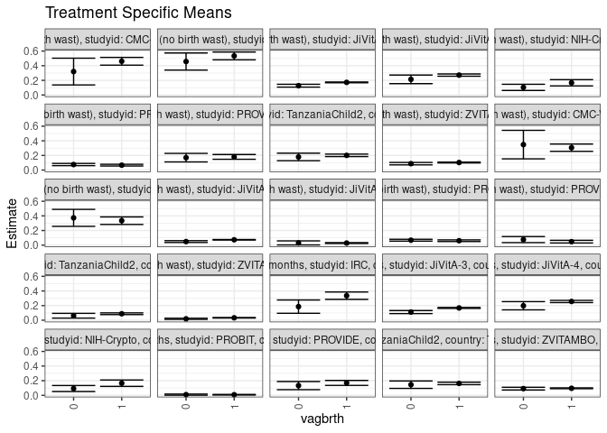

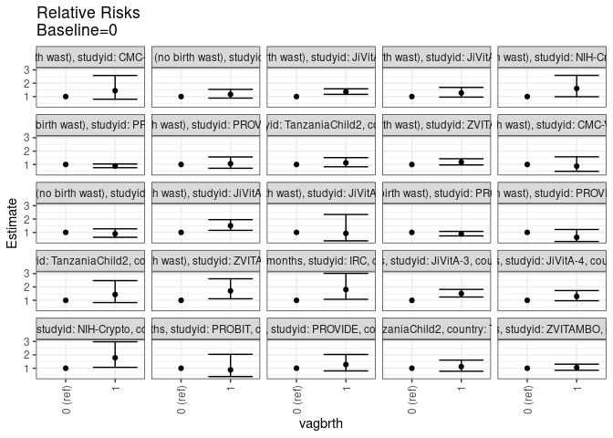

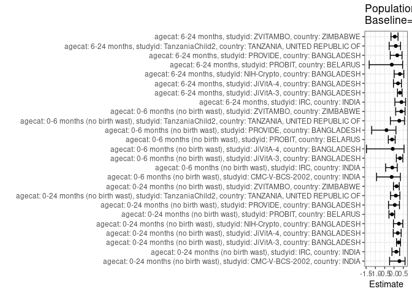

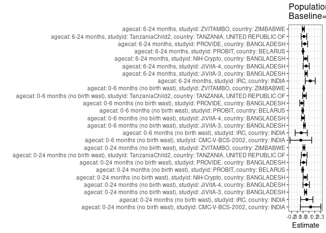

## Results Table

### Parameter: TSM

| agecat | studyid | country | intervention_level | baseline_level | estimate | ci_lower | ci_upper |
| --- | --- | --- | --- | --- | --- | --- | --- |
| 0-24 months (no birth wast) | CMC-V-BCS-2002 | INDIA | 0 | NA | 0.3200000 | 0.1368958 | 0.5031042 |
| 0-24 months (no birth wast) | CMC-V-BCS-2002 | INDIA | 1 | NA | 0.4606414 | 0.4078197 | 0.5134631 |
| 0-24 months (no birth wast) | IRC | INDIA | 0 | NA | 0.4571429 | 0.3403007 | 0.5739850 |
| 0-24 months (no birth wast) | IRC | INDIA | 1 | NA | 0.5339233 | 0.4807556 | 0.5870910 |
| 0-24 months (no birth wast) | JiVitA-3 | BANGLADESH | 0 | NA | 0.1268456 | 0.1076897 | 0.1460016 |
| 0-24 months (no birth wast) | JiVitA-3 | BANGLADESH | 1 | NA | 0.1721923 | 0.1667650 | 0.1776197 |
| 0-24 months (no birth wast) | JiVitA-4 | BANGLADESH | 0 | NA | 0.2135135 | 0.1547580 | 0.2722690 |
| 0-24 months (no birth wast) | JiVitA-4 | BANGLADESH | 1 | NA | 0.2717365 | 0.2562153 | 0.2872577 |
| 0-24 months (no birth wast) | NIH-Crypto | BANGLADESH | 0 | NA | 0.1039604 | 0.0618288 | 0.1460920 |
| 0-24 months (no birth wast) | NIH-Crypto | BANGLADESH | 1 | NA | 0.1666667 | 0.1240238 | 0.2093095 |
| 0-24 months (no birth wast) | PROBIT | BELARUS | 0 | NA | 0.0753074 | 0.0602081 | 0.0904066 |
| 0-24 months (no birth wast) | PROBIT | BELARUS | 1 | NA | 0.0670597 | 0.0551025 | 0.0790169 |
| 0-24 months (no birth wast) | PROVIDE | BANGLADESH | 0 | NA | 0.1698113 | 0.1114080 | 0.2282146 |
| 0-24 months (no birth wast) | PROVIDE | BANGLADESH | 1 | NA | 0.1799242 | 0.1471359 | 0.2127126 |
| 0-24 months (no birth wast) | TanzaniaChild2 | TANZANIA, UNITED REPUBLIC OF | 0 | NA | 0.1792453 | 0.1276033 | 0.2308873 |
| 0-24 months (no birth wast) | TanzaniaChild2 | TANZANIA, UNITED REPUBLIC OF | 1 | NA | 0.2011199 | 0.1841454 | 0.2180944 |
| 0-24 months (no birth wast) | ZVITAMBO | ZIMBABWE | 0 | NA | 0.0875657 | 0.0711711 | 0.1039602 |
| 0-24 months (no birth wast) | ZVITAMBO | ZIMBABWE | 1 | NA | 0.1030695 | 0.0977134 | 0.1084256 |
| 0-6 months (no birth wast) | CMC-V-BCS-2002 | INDIA | 0 | NA | 0.3478261 | 0.1529008 | 0.5427514 |
| 0-6 months (no birth wast) | CMC-V-BCS-2002 | INDIA | 1 | NA | 0.3058104 | 0.2558000 | 0.3558208 |
| 0-6 months (no birth wast) | IRC | INDIA | 0 | NA | 0.3731343 | 0.2571797 | 0.4890889 |
| 0-6 months (no birth wast) | IRC | INDIA | 1 | NA | 0.3343653 | 0.2828504 | 0.3858802 |
| 0-6 months (no birth wast) | JiVitA-3 | BANGLADESH | 0 | NA | 0.0486968 | 0.0359867 | 0.0614070 |
| 0-6 months (no birth wast) | JiVitA-3 | BANGLADESH | 1 | NA | 0.0731697 | 0.0694318 | 0.0769077 |
| 0-6 months (no birth wast) | JiVitA-4 | BANGLADESH | 0 | NA | 0.0307263 | 0.0032182 | 0.0582343 |
| 0-6 months (no birth wast) | JiVitA-4 | BANGLADESH | 1 | NA | 0.0285927 | 0.0232597 | 0.0339258 |
| 0-6 months (no birth wast) | PROBIT | BELARUS | 0 | NA | 0.0676653 | 0.0546908 | 0.0806398 |
| 0-6 months (no birth wast) | PROBIT | BELARUS | 1 | NA | 0.0603781 | 0.0489097 | 0.0718465 |
| 0-6 months (no birth wast) | PROVIDE | BANGLADESH | 0 | NA | 0.0759494 | 0.0346115 | 0.1172872 |
| 0-6 months (no birth wast) | PROVIDE | BANGLADESH | 1 | NA | 0.0476190 | 0.0293892 | 0.0658489 |
| 0-6 months (no birth wast) | TanzaniaChild2 | TANZANIA, UNITED REPUBLIC OF | 0 | NA | 0.0616114 | 0.0291609 | 0.0940619 |
| 0-6 months (no birth wast) | TanzaniaChild2 | TANZANIA, UNITED REPUBLIC OF | 1 | NA | 0.0884831 | 0.0764369 | 0.1005294 |
| 0-6 months (no birth wast) | ZVITAMBO | ZIMBABWE | 0 | NA | 0.0194863 | 0.0114230 | 0.0275495 |
| 0-6 months (no birth wast) | ZVITAMBO | ZIMBABWE | 1 | NA | 0.0332921 | 0.0301001 | 0.0364841 |
| 6-24 months | IRC | INDIA | 0 | NA | 0.1857143 | 0.0945047 | 0.2769239 |
| 6-24 months | IRC | INDIA | 1 | NA | 0.3352941 | 0.2850522 | 0.3855361 |
| 6-24 months | JiVitA-3 | BANGLADESH | 0 | NA | 0.1114106 | 0.0907564 | 0.1320648 |
| 6-24 months | JiVitA-3 | BANGLADESH | 1 | NA | 0.1677123 | 0.1613333 | 0.1740912 |
| 6-24 months | JiVitA-4 | BANGLADESH | 0 | NA | 0.1978320 | 0.1415736 | 0.2540904 |
| 6-24 months | JiVitA-4 | BANGLADESH | 1 | NA | 0.2564598 | 0.2413023 | 0.2716173 |
| 6-24 months | NIH-Crypto | BANGLADESH | 0 | NA | 0.0927835 | 0.0519141 | 0.1336529 |
| 6-24 months | NIH-Crypto | BANGLADESH | 1 | NA | 0.1654676 | 0.1217391 | 0.2091961 |
| 6-24 months | PROBIT | BELARUS | 0 | NA | 0.0093799 | 0.0015144 | 0.0172454 |
| 6-24 months | PROBIT | BELARUS | 1 | NA | 0.0082431 | 0.0041613 | 0.0123248 |
| 6-24 months | PROVIDE | BANGLADESH | 0 | NA | 0.1328671 | 0.0771890 | 0.1885453 |
| 6-24 months | PROVIDE | BANGLADESH | 1 | NA | 0.1694915 | 0.1356167 | 0.2033663 |
| 6-24 months | TanzaniaChild2 | TANZANIA, UNITED REPUBLIC OF | 0 | NA | 0.1451613 | 0.0945243 | 0.1957983 |
| 6-24 months | TanzaniaChild2 | TANZANIA, UNITED REPUBLIC OF | 1 | NA | 0.1624309 | 0.1454343 | 0.1794275 |
| 6-24 months | ZVITAMBO | ZIMBABWE | 0 | NA | 0.0912088 | 0.0725021 | 0.1099155 |
| 6-24 months | ZVITAMBO | ZIMBABWE | 1 | NA | 0.0958932 | 0.0900672 | 0.1017192 |

### Parameter: E(Y)

| agecat | studyid | country | intervention_level | baseline_level | estimate | ci_lower | ci_upper |
| --- | --- | --- | --- | --- | --- | --- | --- |
| 0-24 months (no birth wast) | CMC-V-BCS-2002 | INDIA | NA | NA | 0.4510870 | 0.4001777 | 0.5019962 |
| 0-24 months (no birth wast) | IRC | INDIA | NA | NA | 0.5207824 | 0.4723080 | 0.5692568 |
| 0-24 months (no birth wast) | JiVitA-3 | BANGLADESH | NA | NA | 0.1696334 | 0.1643208 | 0.1749460 |
| 0-24 months (no birth wast) | JiVitA-4 | BANGLADESH | NA | NA | 0.2669482 | 0.2519234 | 0.2819730 |
| 0-24 months (no birth wast) | NIH-Crypto | BANGLADESH | NA | NA | 0.1411290 | 0.1104588 | 0.1717993 |
| 0-24 months (no birth wast) | PROBIT | BELARUS | NA | NA | 0.0680135 | 0.0562135 | 0.0798135 |
| 0-24 months (no birth wast) | PROVIDE | BANGLADESH | NA | NA | 0.1775837 | 0.1489858 | 0.2061816 |
| 0-24 months (no birth wast) | TanzaniaChild2 | TANZANIA, UNITED REPUBLIC OF | NA | NA | 0.1991507 | 0.1830179 | 0.2152836 |
| 0-24 months (no birth wast) | ZVITAMBO | ZIMBABWE | NA | NA | 0.1017601 | 0.0966641 | 0.1068561 |
| 0-6 months (no birth wast) | CMC-V-BCS-2002 | INDIA | NA | NA | 0.3085714 | 0.2601110 | 0.3570318 |
| 0-6 months (no birth wast) | IRC | INDIA | NA | NA | 0.3410256 | 0.2939169 | 0.3881343 |
| 0-6 months (no birth wast) | JiVitA-3 | BANGLADESH | NA | NA | 0.0718055 | 0.0681632 | 0.0754477 |
| 0-6 months (no birth wast) | JiVitA-4 | BANGLADESH | NA | NA | 0.0287671 | 0.0234680 | 0.0340662 |
| 0-6 months (no birth wast) | PROBIT | BELARUS | NA | NA | 0.0612233 | 0.0502388 | 0.0722078 |
| 0-6 months (no birth wast) | PROVIDE | BANGLADESH | NA | NA | 0.0541728 | 0.0371844 | 0.0711612 |
| 0-6 months (no birth wast) | TanzaniaChild2 | TANZANIA, UNITED REPUBLIC OF | NA | NA | 0.0860673 | 0.0747182 | 0.0974164 |
| 0-6 months (no birth wast) | ZVITAMBO | ZIMBABWE | NA | NA | 0.0321170 | 0.0291164 | 0.0351176 |
| 6-24 months | IRC | INDIA | NA | NA | 0.3097561 | 0.2649438 | 0.3545684 |
| 6-24 months | JiVitA-3 | BANGLADESH | NA | NA | 0.1640716 | 0.1579211 | 0.1702221 |
| 6-24 months | JiVitA-4 | BANGLADESH | NA | NA | 0.2516630 | 0.2368610 | 0.2664649 |
| 6-24 months | NIH-Crypto | BANGLADESH | NA | NA | 0.1355932 | 0.1046749 | 0.1665115 |
| 6-24 months | PROBIT | BELARUS | NA | NA | 0.0083745 | 0.0044130 | 0.0123360 |
| 6-24 months | PROVIDE | BANGLADESH | NA | NA | 0.1609756 | 0.1319065 | 0.1900447 |
| 6-24 months | TanzaniaChild2 | TANZANIA, UNITED REPUBLIC OF | NA | NA | 0.1608216 | 0.1447012 | 0.1769421 |
| 6-24 months | ZVITAMBO | ZIMBABWE | NA | NA | 0.0954957 | 0.0899327 | 0.1010586 |

### Parameter: RR

| agecat | studyid | country | intervention_level | baseline_level | estimate | ci_lower | ci_upper |
| --- | --- | --- | --- | --- | --- | --- | --- |
| 0-24 months (no birth wast) | CMC-V-BCS-2002 | INDIA | 0 | 0 | 1.0000000 | 1.0000000 | 1.000000 |
| 0-24 months (no birth wast) | CMC-V-BCS-2002 | INDIA | 1 | 0 | 1.4395044 | 0.8030978 | 2.580225 |
| 0-24 months (no birth wast) | IRC | INDIA | 0 | 0 | 1.0000000 | 1.0000000 | 1.000000 |
| 0-24 months (no birth wast) | IRC | INDIA | 1 | 0 | 1.1679572 | 0.8877643 | 1.536584 |
| 0-24 months (no birth wast) | JiVitA-3 | BANGLADESH | 0 | 0 | 1.0000000 | 1.0000000 | 1.000000 |
| 0-24 months (no birth wast) | JiVitA-3 | BANGLADESH | 1 | 0 | 1.3574952 | 1.1660406 | 1.580385 |
| 0-24 months (no birth wast) | JiVitA-4 | BANGLADESH | 0 | 0 | 1.0000000 | 1.0000000 | 1.000000 |
| 0-24 months (no birth wast) | JiVitA-4 | BANGLADESH | 1 | 0 | 1.2726899 | 0.9607719 | 1.685873 |
| 0-24 months (no birth wast) | NIH-Crypto | BANGLADESH | 0 | 0 | 1.0000000 | 1.0000000 | 1.000000 |
| 0-24 months (no birth wast) | NIH-Crypto | BANGLADESH | 1 | 0 | 1.6031746 | 0.9927383 | 2.588969 |
| 0-24 months (no birth wast) | PROBIT | BELARUS | 0 | 0 | 1.0000000 | 1.0000000 | 1.000000 |
| 0-24 months (no birth wast) | PROBIT | BELARUS | 1 | 0 | 0.8904797 | 0.7613448 | 1.041518 |
| 0-24 months (no birth wast) | PROVIDE | BANGLADESH | 0 | 0 | 1.0000000 | 1.0000000 | 1.000000 |
| 0-24 months (no birth wast) | PROVIDE | BANGLADESH | 1 | 0 | 1.0595539 | 0.7179331 | 1.563731 |
| 0-24 months (no birth wast) | TanzaniaChild2 | TANZANIA, UNITED REPUBLIC OF | 0 | 0 | 1.0000000 | 1.0000000 | 1.000000 |
| 0-24 months (no birth wast) | TanzaniaChild2 | TANZANIA, UNITED REPUBLIC OF | 1 | 0 | 1.1220375 | 0.8310464 | 1.514919 |
| 0-24 months (no birth wast) | ZVITAMBO | ZIMBABWE | 0 | 0 | 1.0000000 | 1.0000000 | 1.000000 |
| 0-24 months (no birth wast) | ZVITAMBO | ZIMBABWE | 1 | 0 | 1.1770533 | 0.9691951 | 1.429490 |
| 0-6 months (no birth wast) | CMC-V-BCS-2002 | INDIA | 0 | 0 | 1.0000000 | 1.0000000 | 1.000000 |
| 0-6 months (no birth wast) | CMC-V-BCS-2002 | INDIA | 1 | 0 | 0.8792049 | 0.4904064 | 1.576246 |
| 0-6 months (no birth wast) | IRC | INDIA | 0 | 0 | 1.0000000 | 1.0000000 | 1.000000 |
| 0-6 months (no birth wast) | IRC | INDIA | 1 | 0 | 0.8960991 | 0.6334601 | 1.267631 |
| 0-6 months (no birth wast) | JiVitA-3 | BANGLADESH | 0 | 0 | 1.0000000 | 1.0000000 | 1.000000 |
| 0-6 months (no birth wast) | JiVitA-3 | BANGLADESH | 1 | 0 | 1.5025562 | 1.1551639 | 1.954420 |
| 0-6 months (no birth wast) | JiVitA-4 | BANGLADESH | 0 | 0 | 1.0000000 | 1.0000000 | 1.000000 |
| 0-6 months (no birth wast) | JiVitA-4 | BANGLADESH | 1 | 0 | 0.9305637 | 0.3699269 | 2.340865 |
| 0-6 months (no birth wast) | PROBIT | BELARUS | 0 | 0 | 1.0000000 | 1.0000000 | 1.000000 |
| 0-6 months (no birth wast) | PROBIT | BELARUS | 1 | 0 | 0.8923057 | 0.7382256 | 1.078545 |
| 0-6 months (no birth wast) | PROVIDE | BANGLADESH | 0 | 0 | 1.0000000 | 1.0000000 | 1.000000 |
| 0-6 months (no birth wast) | PROVIDE | BANGLADESH | 1 | 0 | 0.6269841 | 0.3223025 | 1.219690 |
| 0-6 months (no birth wast) | TanzaniaChild2 | TANZANIA, UNITED REPUBLIC OF | 0 | 0 | 1.0000000 | 1.0000000 | 1.000000 |
| 0-6 months (no birth wast) | TanzaniaChild2 | TANZANIA, UNITED REPUBLIC OF | 1 | 0 | 1.4361495 | 0.8335668 | 2.474337 |
| 0-6 months (no birth wast) | ZVITAMBO | ZIMBABWE | 0 | 0 | 1.0000000 | 1.0000000 | 1.000000 |
| 0-6 months (no birth wast) | ZVITAMBO | ZIMBABWE | 1 | 0 | 1.7084916 | 1.1172365 | 2.612646 |
| 6-24 months | IRC | INDIA | 0 | 0 | 1.0000000 | 1.0000000 | 1.000000 |
| 6-24 months | IRC | INDIA | 1 | 0 | 1.8054299 | 1.0803876 | 3.017044 |
| 6-24 months | JiVitA-3 | BANGLADESH | 0 | 0 | 1.0000000 | 1.0000000 | 1.000000 |
| 6-24 months | JiVitA-3 | BANGLADESH | 1 | 0 | 1.5053530 | 1.2464932 | 1.817970 |
| 6-24 months | JiVitA-4 | BANGLADESH | 0 | 0 | 1.0000000 | 1.0000000 | 1.000000 |
| 6-24 months | JiVitA-4 | BANGLADESH | 1 | 0 | 1.2963516 | 0.9714678 | 1.729885 |
| 6-24 months | NIH-Crypto | BANGLADESH | 0 | 0 | 1.0000000 | 1.0000000 | 1.000000 |
| 6-24 months | NIH-Crypto | BANGLADESH | 1 | 0 | 1.7833733 | 1.0669775 | 2.980775 |
| 6-24 months | PROBIT | BELARUS | 0 | 0 | 1.0000000 | 1.0000000 | 1.000000 |
| 6-24 months | PROBIT | BELARUS | 1 | 0 | 0.8788027 | 0.3784339 | 2.040764 |
| 6-24 months | PROVIDE | BANGLADESH | 0 | 0 | 1.0000000 | 1.0000000 | 1.000000 |
| 6-24 months | PROVIDE | BANGLADESH | 1 | 0 | 1.2756467 | 0.8018618 | 2.029370 |
| 6-24 months | TanzaniaChild2 | TANZANIA, UNITED REPUBLIC OF | 0 | 0 | 1.0000000 | 1.0000000 | 1.000000 |
| 6-24 months | TanzaniaChild2 | TANZANIA, UNITED REPUBLIC OF | 1 | 0 | 1.1189687 | 0.7774146 | 1.610583 |
| 6-24 months | ZVITAMBO | ZIMBABWE | 0 | 0 | 1.0000000 | 1.0000000 | 1.000000 |
| 6-24 months | ZVITAMBO | ZIMBABWE | 1 | 0 | 1.0513592 | 0.8488918 | 1.302117 |

### Parameter: PAR

| agecat | studyid | country | intervention_level | baseline_level | estimate | ci_lower | ci_upper |
| --- | --- | --- | --- | --- | --- | --- | --- |
| 0-24 months (no birth wast) | CMC-V-BCS-2002 | INDIA | 0 | NA | 0.1310870 | -0.0465745 | 0.3087484 |
| 0-24 months (no birth wast) | IRC | INDIA | 0 | NA | 0.0636395 | -0.0427971 | 0.1700762 |
| 0-24 months (no birth wast) | JiVitA-3 | BANGLADESH | 0 | NA | 0.0427878 | 0.0243635 | 0.0612120 |
| 0-24 months (no birth wast) | JiVitA-4 | BANGLADESH | 0 | NA | 0.0534347 | -0.0024178 | 0.1092871 |
| 0-24 months (no birth wast) | NIH-Crypto | BANGLADESH | 0 | NA | 0.0371686 | 0.0015328 | 0.0728045 |
| 0-24 months (no birth wast) | PROBIT | BELARUS | 0 | NA | -0.0072939 | -0.0174684 | 0.0028807 |
| 0-24 months (no birth wast) | PROVIDE | BANGLADESH | 0 | NA | 0.0077724 | -0.0437050 | 0.0592497 |
| 0-24 months (no birth wast) | TanzaniaChild2 | TANZANIA, UNITED REPUBLIC OF | 0 | NA | 0.0199055 | -0.0295618 | 0.0693727 |
| 0-24 months (no birth wast) | ZVITAMBO | ZIMBABWE | 0 | NA | 0.0141944 | -0.0015964 | 0.0299852 |
| 0-6 months (no birth wast) | CMC-V-BCS-2002 | INDIA | 0 | NA | -0.0392547 | -0.2272721 | 0.1487628 |
| 0-6 months (no birth wast) | IRC | INDIA | 0 | NA | -0.0321087 | -0.1372038 | 0.0729864 |
| 0-6 months (no birth wast) | JiVitA-3 | BANGLADESH | 0 | NA | 0.0231086 | 0.0108033 | 0.0354139 |
| 0-6 months (no birth wast) | JiVitA-4 | BANGLADESH | 0 | NA | -0.0019591 | -0.0278993 | 0.0239810 |
| 0-6 months (no birth wast) | PROBIT | BELARUS | 0 | NA | -0.0064420 | -0.0172664 | 0.0043823 |
| 0-6 months (no birth wast) | PROVIDE | BANGLADESH | 0 | NA | -0.0217766 | -0.0565158 | 0.0129626 |
| 0-6 months (no birth wast) | TanzaniaChild2 | TANZANIA, UNITED REPUBLIC OF | 0 | NA | 0.0244559 | -0.0070480 | 0.0559598 |
| 0-6 months (no birth wast) | ZVITAMBO | ZIMBABWE | 0 | NA | 0.0126307 | 0.0046966 | 0.0205649 |
| 6-24 months | IRC | INDIA | 0 | NA | 0.1240418 | 0.0375165 | 0.2105672 |
| 6-24 months | JiVitA-3 | BANGLADESH | 0 | NA | 0.0526610 | 0.0325472 | 0.0727748 |
| 6-24 months | JiVitA-4 | BANGLADESH | 0 | NA | 0.0538310 | 0.0007392 | 0.1069228 |
| 6-24 months | NIH-Crypto | BANGLADESH | 0 | NA | 0.0428097 | 0.0074091 | 0.0782103 |
| 6-24 months | PROBIT | BELARUS | 0 | NA | -0.0010054 | -0.0078622 | 0.0058515 |
| 6-24 months | PROVIDE | BANGLADESH | 0 | NA | 0.0281085 | -0.0219257 | 0.0781426 |
| 6-24 months | TanzaniaChild2 | TANZANIA, UNITED REPUBLIC OF | 0 | NA | 0.0156604 | -0.0327761 | 0.0640968 |
| 6-24 months | ZVITAMBO | ZIMBABWE | 0 | NA | 0.0042869 | -0.0136434 | 0.0222171 |

### Parameter: PAF

| agecat | studyid | country | intervention_level | baseline_level | estimate | ci_lower | ci_upper |
| --- | --- | --- | --- | --- | --- | --- | --- |
| 0-24 months (no birth wast) | CMC-V-BCS-2002 | INDIA | 0 | NA | 0.2906024 | -0.2363609 | 0.5929627 |
| 0-24 months (no birth wast) | IRC | INDIA | 0 | NA | 0.1221999 | -0.1082930 | 0.3047569 |
| 0-24 months (no birth wast) | JiVitA-3 | BANGLADESH | 0 | NA | 0.2522366 | 0.1350424 | 0.3535520 |
| 0-24 months (no birth wast) | JiVitA-4 | BANGLADESH | 0 | NA | 0.2001688 | -0.0402976 | 0.3850510 |
| 0-24 months (no birth wast) | NIH-Crypto | BANGLADESH | 0 | NA | 0.2633663 | -0.0308441 | 0.4736069 |
| 0-24 months (no birth wast) | PROBIT | BELARUS | 0 | NA | -0.1072415 | -0.2700321 | 0.0346829 |
| 0-24 months (no birth wast) | PROVIDE | BANGLADESH | 0 | NA | 0.0437674 | -0.2947761 | 0.2937923 |
| 0-24 months (no birth wast) | TanzaniaChild2 | TANZANIA, UNITED REPUBLIC OF | 0 | NA | 0.0999517 | -0.1860012 | 0.3169595 |
| 0-24 months (no birth wast) | ZVITAMBO | ZIMBABWE | 0 | NA | 0.1394891 | -0.0304082 | 0.2813731 |
| 0-6 months (no birth wast) | CMC-V-BCS-2002 | INDIA | 0 | NA | -0.1272142 | -0.9353750 | 0.3434803 |
| 0-6 months (no birth wast) | IRC | INDIA | 0 | NA | -0.0941533 | -0.4501527 | 0.1744515 |
| 0-6 months (no birth wast) | JiVitA-3 | BANGLADESH | 0 | NA | 0.3218225 | 0.1265910 | 0.4734143 |
| 0-6 months (no birth wast) | JiVitA-4 | BANGLADESH | 0 | NA | -0.0681032 | -1.4789041 | 0.5397787 |
| 0-6 months (no birth wast) | PROBIT | BELARUS | 0 | NA | -0.1052218 | -0.3044913 | 0.0636080 |
| 0-6 months (no birth wast) | PROVIDE | BANGLADESH | 0 | NA | -0.4019843 | -1.1985729 | 0.1059838 |
| 0-6 months (no birth wast) | TanzaniaChild2 | TANZANIA, UNITED REPUBLIC OF | 0 | NA | 0.2841490 | -0.1909202 | 0.5697087 |
| 0-6 months (no birth wast) | ZVITAMBO | ZIMBABWE | 0 | NA | 0.3932725 | 0.0923109 | 0.5944446 |
| 6-24 months | IRC | INDIA | 0 | NA | 0.4004499 | 0.0490764 | 0.6219883 |
| 6-24 months | JiVitA-3 | BANGLADESH | 0 | NA | 0.3209634 | 0.1868215 | 0.4329773 |
| 6-24 months | JiVitA-4 | BANGLADESH | 0 | NA | 0.2139011 | -0.0299002 | 0.3999890 |
| 6-24 months | NIH-Crypto | BANGLADESH | 0 | NA | 0.3157216 | 0.0093736 | 0.5273326 |
| 6-24 months | PROBIT | BELARUS | 0 | NA | -0.1200528 | -1.3324879 | 0.4621545 |
| 6-24 months | PROVIDE | BANGLADESH | 0 | NA | 0.1746133 | -0.2012267 | 0.4328604 |
| 6-24 months | TanzaniaChild2 | TANZANIA, UNITED REPUBLIC OF | 0 | NA | 0.0973771 | -0.2599959 | 0.3533884 |
| 6-24 months | ZVITAMBO | ZIMBABWE | 0 | NA | 0.0448908 | -0.1625778 | 0.2153354 |